# 02-DataVisualization-seaborn

#### Seaborn Histogram

Histograms represent the data distribution by forming bins along the range of the data and then drawing bars to show the number of observations that fall in each bin.

We can use the same **distplot()** function to plot a histogram as follows:-

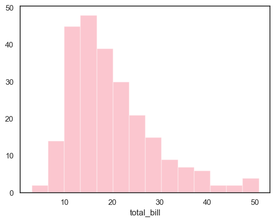

```python
sns.distplot(tips['total_bill'], kde=False)

plt.show()
```

#### Seaborn – Kernel Density Estimates

Kernel Density Estimation (KDE) is a way to estimate the probability density function of a continuous random variable. It is used for non-parametric analysis.

Setting the hist parameter to false in distplot() function will yield the kernel density estimation plot.

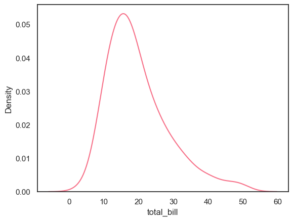

```python
sns.distplot(tips['total_bill'], hist=False)

plt.show()
```

#### Plotting Bivariate Distribution with jointplot()

Bivariate Distribution serves the purpose of examining the connection between two variables, specifically how one variable behaves concerning the other.

For analyzing Bivariate Distribution effectively in seaborn, the recommended approach is to employ the jointplot() function.

Jointplot() constructs a multi-panel visualization that illustrates the bivariate correlation between two variables while also displaying the univariate distributions of each variable on distinct axes.

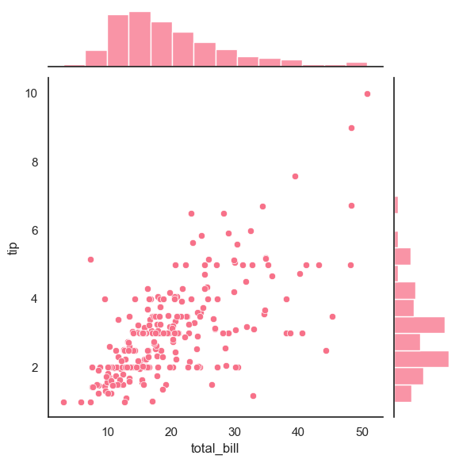

```python
sns.jointplot(x="total_bill", y="tip", data=tips)

plt.show()
```

#### Seaborn - Scatter plot

To showcase the association between two variables, x and y, a scatter plot can be employed. A basic scatter plot can be created in the following manner:

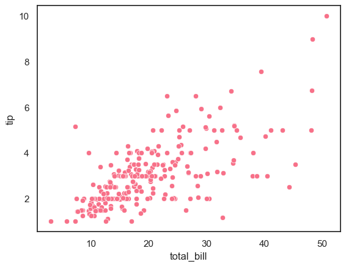

```python
sns.scatterplot(x="total_bill", y="tip", data=tips)

plt.show()
```

#### Visualizing pairwise relationship with pairplot()

In datasets with numerous variables, it becomes essential to assess the relationships between each pair of variables. To visualize these pairwise relationships, the pairplot() function is employed. This function generates a matrix of plots that illustrates the (n,2) combinations of variables within a dataframe, with diagonal plots displaying univariate distributions.

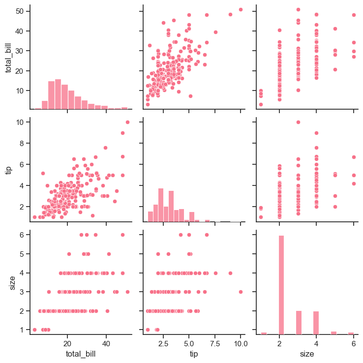

```python
sns.set_style("ticks")

sns.pairplot(tips)

plt.show()
```

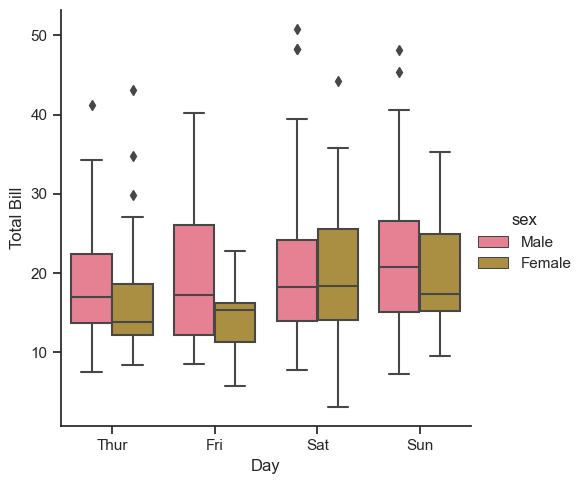

```python
with sns.axes_style(style='ticks'):
    g = sns.catplot(x="day", y="total_bill", hue="sex", data=tips, kind="box")
    g.set_axis_labels("Day", "Total Bill")
```

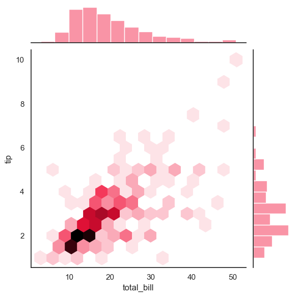

```python
with sns.axes_style('white'):
    sns.jointplot(x="total_bill", y="tip", data=tips, kind='hex')
```

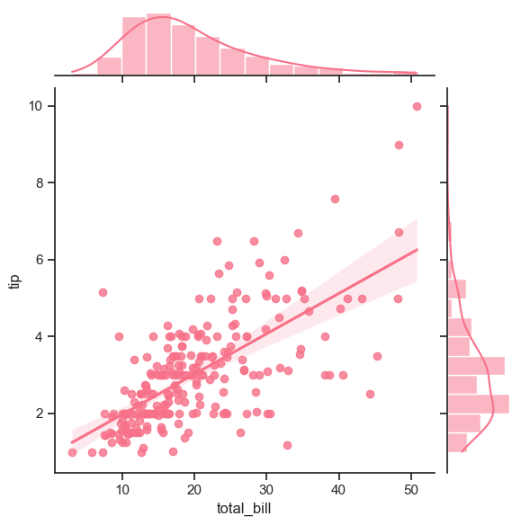

```python
sns.jointplot(x="total_bill", y="tip", data=tips, kind='reg')
```